# Shah-Pratik-HomeWork4

Pratik, Celeste

April 15, 2019

## 1

### 1 Using the KamilarAndCooperData.csv dataset, run a linear regression looking at log(HomeRange_km2) in relation to log(Body_mass_female_mean) and report your ?? coeffiecients (slope and intercept).

```r
f <- curl("https://raw.githubusercontent.com/difiore/ADA-2019/master/KamilarAndCooperData.csv")
d <- read_csv(f, col_names = TRUE)
head(d)
```

```
## # A tibble: 6 x 44
##   Scientific_Name Family Genus Species Brain_Size_Spec~ Brain_Size_Fema~
##   <chr>           <chr>  <chr> <chr>              <dbl>            <dbl>
## 1 Allenopithecus~ Cerco~ Alle~ nigrov~             58.0             53.7
## 2 Allocebus_tric~ Cerco~ Allo~ tricho~             NA               NA
## 3 Alouatta_belze~ Ateli~ Alou~ belzeb~             52.8             51.2
## 4 Alouatta_caraya Ateli~ Alou~ caraya              52.6             47.8
## 5 Alouatta_guari~ Ateli~ Alou~ guariba             51.7             49.1
## 6 Alouatta_palli~ Ateli~ Alou~ pallia~             49.9             48.0
## # ... with 38 more variables: Brain_size_Ref <chr>,
## #   Body_mass_male_mean <dbl>, Body_mass_female_mean <dbl>,
## #   Mass_Dimorphism <dbl>, Mass_Ref <chr>, MeanGroupSize <dbl>,
## #   AdultMales <dbl>, AdultFemale <dbl>, AdultSexRatio <dbl>,
## #   Social_Organization_Ref <chr>, InterbirthInterval_d <dbl>,
## #   Gestation <dbl>, WeaningAge_d <dbl>, MaxLongevity_m <dbl>,
## #   LitterSz <dbl>, Life_History_Ref <chr>, GR_MidRangeLat_dd <dbl>,
## #   Precip_Mean_mm <dbl>, Temp_Mean_degC <dbl>, AET_Mean_mm <dbl>,
## #   PET_Mean_mm <dbl>, Climate_Ref <chr>, HomeRange_km2 <dbl>,
## #   HomeRangeRef <chr>, DayLength_km <dbl>, DayLengthRef <chr>,
## #   Territoriality <dbl>, Fruit <dbl>, Leaves <chr>, Fauna <chr>,
## #   DietRef1 <chr>, Canine_Dimorphism <dbl>, Canine_Dimorphism_Ref <chr>,
## #   Feed <dbl>, Move <dbl>, Rest <dbl>, Social <dbl>,
## #   Activity_Budget_Ref <chr>
```

```r
m <- lm(log(d$HomeRange_km2)~log(d$Body_mass_female_mean), data = d)
m
```

```
##
## Call:
## lm(formula = log(d$HomeRange_km2) ~ log(d$Body_mass_female_mean),
##     data = d)
##
## Coefficients:
##                  (Intercept)  log(d$Body_mass_female_mean)
##                       -9.441                         1.036
```

```r
names(m)
```

```
##  [1] "coefficients"  "residuals"     "effects"       "rank"
##  [5] "fitted.values" "assign"        "qr"            "df.residual"
##  [9] "na.action"     "xlevels"       "call"          "terms"
## [13] "model"
```

```r
m$coefficients ##Beta0 = -9.44 and Beta1 = 1.036
```

```
##                  (Intercept) log(d$Body_mass_female_mean)
##                    -9.441231                     1.036432
```

### [2] Then, use bootstrapping to sample from your data 1000 times with replacement, each time fitting the same model and calculating the appropriate coefficients.The size of each sample should be equivalent to the number of observations in your dataset.This generates a sampling distribution for each β coefficient.

Plot a histogram of these sampling distributions.

```r
log(d$HomeRange_km2)
```

[output not shown]

[output cut: 28 more lines]

```r
log(d$Body_mass_female_mean)
```

[output not shown]

[output cut: 16 more lines]

```r
length(d$Body_mass_female_mean) #n = 213
```

```
## [1] 213
```

```r
sim <-NULL
n<- 213
for (i in 1:1000) {
  a<- d[sample(nrow(d),size=n, replace = TRUE),]
  b<- lm(data=a, log(a$HomeRange_km2)~ log(a$Body_mass_female_mean))
  sim[i]<- list(b$coefficients)
}
head(sim)
```

```
## [[1]]
##                  (Intercept) log(a$Body_mass_female_mean)
##                    -9.695691                     1.054648
##
## [[2]]
##                  (Intercept) log(a$Body_mass_female_mean)
##                   -9.1518931                    0.9865732
##
## [[3]]
##                  (Intercept) log(a$Body_mass_female_mean)
##                    -9.783635                     1.079276
##
## [[4]]
##                  (Intercept) log(a$Body_mass_female_mean)
##                    -8.714565                     0.939585
##
## [[5]]
##                  (Intercept) log(a$Body_mass_female_mean)
##                    -9.944847                     1.127232
##
## [[6]]
##                  (Intercept) log(a$Body_mass_female_mean)
##                   -9.1324909                    0.9966998
```

```r
h<-do.call(rbind,sim)
h<- as.data.frame(h)
colnames(h)<- c("Beta_0","Beta_1")
head(h)
```

```
##      Beta_0    Beta_1
## 1 -9.695691 1.0546482
## 2 -9.151893 0.9865732
## 3 -9.783635 1.0792764
## 4 -8.714565 0.9395850
## 5 -9.944847 1.1272325
## 6 -9.132491 0.9966998
```

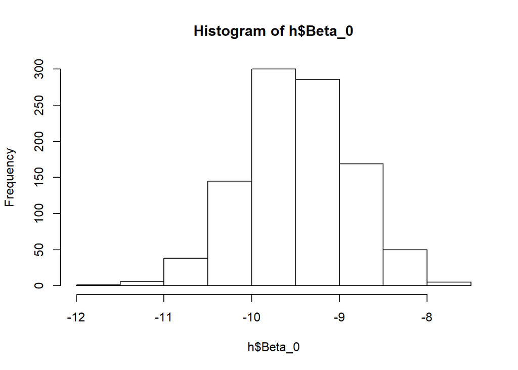

```r
hist(h$Beta_0)
```

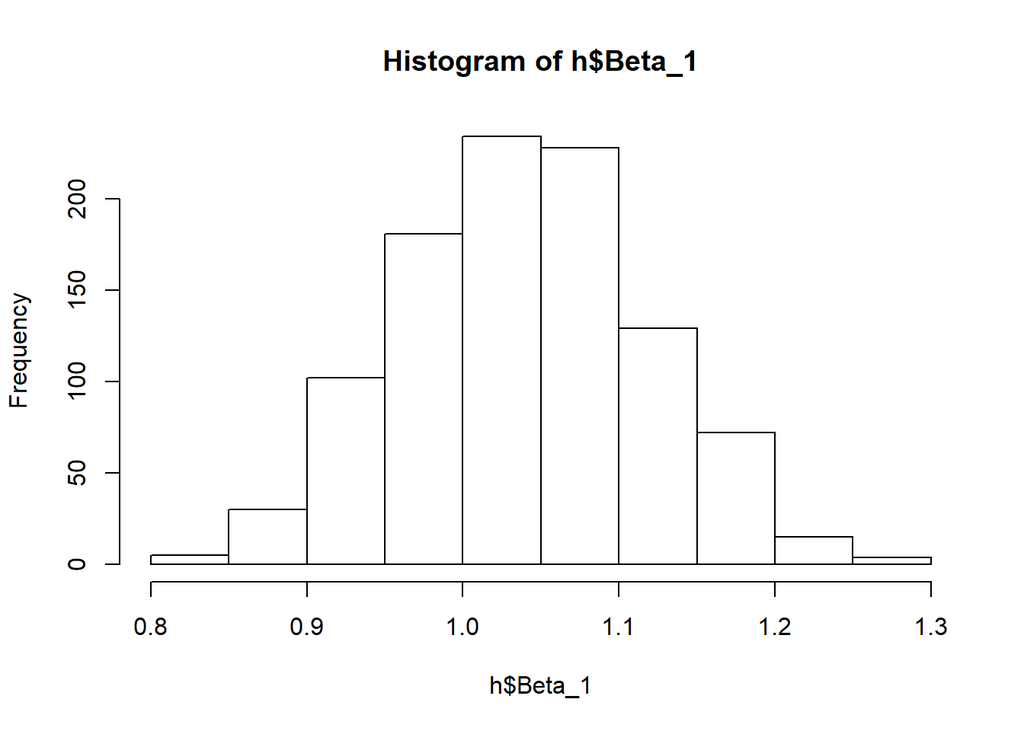

```r
hist(h$Beta_1)
```

### [3] Estimate the standard error for each of your ?? coefficients as the standard deviation of the sampling distribution from your bootstrap.

```r
se <- function(x) sqrt(var(x)/length(x))
se(h$Beta_0)
```

```
## [1] 0.01949324
```

```r
se(h$Beta_1)
```

```
## [1] 0.002499938
```

### [4] Also determine the 95% CI for each of your beta coefficients based on the appropriate quantiles from your sampling distribution.

```r
#CI for Beta 0
quantile(h$Beta_0, c(0.025, 0.975))
```

```
##       2.5%      97.5%
## -10.729801  -8.331906
```

```r
#CI for Beta 1
quantile(h$Beta_1, c(0.025, 0.975))
```

```
##      2.5%     97.5%
## 0.8940701 1.1919314
```

### [5] How does your answer to part [3] compare to the SE estimated from your entire dataset using the formula for standard error implemented in lm()?

# [6] How does your answer to part [4] compare to the 95% CI estimated from your entire dataset?

```r
alpha<- 0.05
mCI<- confint(m, level = 1-alpha)
mCI
```

```
##                                    2.5 %    97.5 %
## (Intercept)                  -10.7720889 -8.110374
## log(d$Body_mass_female_mean)   0.8685707  1.204292
```

```r
quantile(h$Beta_0, c(0.025, 0.975))
```

```
##       2.5%      97.5%
## -10.729801  -8.331906
```

```r
quantile(h$Beta_1, c(0.025, 0.975))
```

```
##      2.5%     97.5%
## 0.8940701 1.1919314
```